# Part A

## 1. Read and Analyse Dataset. [5 Marks]

- A. Clearly write outcome of data analysis(Minimum 2 points) [2 Marks]
- B. Clean the Structured Data [3 Marks]
  - i. Missing value analysis and imputation. [1 Marks]
  - ii. Eliminate Non-English textual data. [2 Marks]
    - Hint: Refer ‘langdetect’ library to detect language of the input text)

```python
!pip install langdetect
```

```
     |████████████████████████████████| 981 kB 5.2 MB/s
```

```python
# Importing all the necessary libraries

import numpy as np
import pandas as pd
import seaborn as sns
import matplotlib.pyplot as plt
%matplotlib inline
from matplotlib.pyplot import figure

from sklearn.preprocessing import LabelEncoder

from sklearn.model_selection import train_test_split

from sklearn.multiclass import OneVsRestClassifier
from sklearn.linear_model import LogisticRegression
from sklearn.svm import SVC, LinearSVC
from sklearn.tree import DecisionTreeClassifier
from sklearn.ensemble import RandomForestClassifier

from sklearn import metrics
from sklearn.metrics import classification_report, confusion_matrix

import nltk
from nltk.corpus import stopwords
nltk.download('stopwords')
from nltk import tokenize
from tensorflow.keras.preprocessing.text import Tokenizer

import re
import pickle
import os
from langdetect import detect

from sklearn.feature_extraction.text import CountVectorizer
from sklearn.feature_extraction.text import TfidfVectorizer
```

```python
#Initialize the random number generator
import random
random.seed(0)

# Ignore the warnings
import warnings
warnings.filterwarnings("ignore")
```

```python
# Mounting Google Drive
from google.colab import drive
drive.mount('/content/drive')
```

```python
dataset_path = "/content/drive/My Drive/Colab Notebooks/NLP/Project 1/"
os.chdir(dataset_path)

# Load the full set of the data
raw_df = pd.read_csv("blogtext.csv")

print("-------------------------------------")
print("Dataset is imported")
print("-------------------------------------")
```

```
-------------------------------------
Dataset is imported
-------------------------------------
```

```python
raw_df.head()
```

|  | id | gender | age | topic | sign | date | text |
| --- | --- | --- | --- | --- | --- | --- | --- |
| 0 | 2059027 | male | 15 | Student | Leo | 14,May,2004 | Info has been found (+/- 100 pages,... |
| 1 | 2059027 | male | 15 | Student | Leo | 13,May,2004 | These are the team members: Drewe... |
| 2 | 2059027 | male | 15 | Student | Leo | 12,May,2004 | In het kader van kernfusie op aarde... |
| 3 | 2059027 | male | 15 | Student | Leo | 12,May,2004 | testing!!! testing!!! |
| 4 | 3581210 | male | 33 | InvestmentBanking | Aquarius | 11,June,2004 | Thanks to Yahoo!'s Toolbar I can ... |

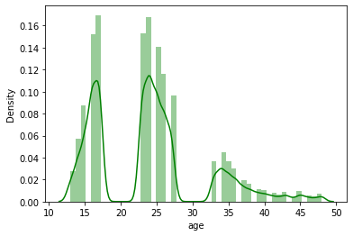

```python
sns.distplot(raw_df['age'],color='green')
```

There are similar numbers of "10s" and "20s" blogs. But "30s" blogs are just about 1/3rd of them

```python
print("--------------------------------------------------------")
print('Dataset Shape: {}'.format(raw_df.shape))
print("--------------------------------------------------------")
print('Total Number of rows in dataset: {}'.format(raw_df.shape[0]))
print("--------------------------------------------------------")
print('Total Number of columns in dataset: {}'.format(raw_df.shape[1]))
print("--------------------------------------------------------")
```

```
--------------------------------------------------------
Dataset Shape: (681284, 7)
--------------------------------------------------------
Total Number of rows in dataset: 681284
--------------------------------------------------------
Total Number of columns in dataset: 7
--------------------------------------------------------
```

Only a portion of the dataset will be used for this project

```python
# Load partial set of the data (5000 rows)
raw_df = pd.read_csv("blogtext.csv",nrows=5000)

print("-------------------------------------")
print("Partial Dataset is imported (5000 rows)")
print("-------------------------------------")
```

```
-------------------------------------
Partial Dataset is imported (5000 rows)
-------------------------------------
```

```python
print("--------------------------------------------------------")
print('Dataset Shape: {}'.format(raw_df.shape))
print("--------------------------------------------------------")
print('Total Number of rows in dataset: {}'.format(raw_df.shape[0]))
print("--------------------------------------------------------")
print('Total Number of columns in dataset: {}'.format(raw_df.shape[1]))
print("--------------------------------------------------------")
```

```
--------------------------------------------------------
Dataset Shape: (5000, 7)
--------------------------------------------------------
Total Number of rows in dataset: 5000
--------------------------------------------------------
Total Number of columns in dataset: 7
--------------------------------------------------------
```

```python
raw_df.info()
```

```
<class 'pandas.core.frame.DataFrame'>
RangeIndex: 5000 entries, 0 to 4999
Data columns (total 7 columns):
 #   Column  Non-Null Count  Dtype
---  ------  --------------  -----
 0   id      5000 non-null   int64
 1   gender  5000 non-null   object
 2   age     5000 non-null   int64
 3   topic   5000 non-null   object
 4   sign    5000 non-null   object
 5   date    5000 non-null   object
 6   text    5000 non-null   object
dtypes: int64(2), object(5)
memory usage: 273.6+ KB
```

There are no null values observed

```python
raw_df['topic'].unique()
```

```
array(['Student', 'InvestmentBanking', 'indUnk', 'Non-Profit', 'Banking',
       'Education', 'Engineering', 'Science', 'Communications-Media',
       'BusinessServices', 'Sports-Recreation', 'Arts', 'Internet',
       'Museums-Libraries', 'Accounting', 'Technology', 'Law',
       'Consulting', 'Automotive', 'Religion'], dtype=object)
```

```python
raw_df['age'].describe()
```

```
count    5000.000000
mean       29.544600
std         7.766008
min        14.000000
25%        24.000000
50%        35.000000
75%        35.000000
max        46.000000
Name: age, dtype: float64
```

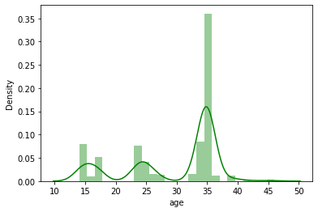

```python
sns.distplot(raw_df['age'],color='green')
```

When considering 5000 rows from the original dataset, the "10s" and "20s" blogs are just 1/3rd of the "30s" blogs

```python
raw_df.gender.value_counts()
```

```
male      3294
female    1706
Name: gender, dtype: int64
```

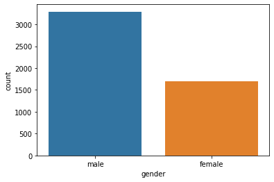

```python
sns.countplot(x='gender',data=raw_df)
```

Male bloggers are double that of female bloggers based on the partial dataset

```python
raw_df['sign'].unique()
```

```
array(['Leo', 'Aquarius', 'Aries', 'Capricorn', 'Gemini', 'Cancer',
       'Sagittarius', 'Scorpio', 'Libra', 'Virgo', 'Taurus', 'Pisces'],
      dtype=object)
```

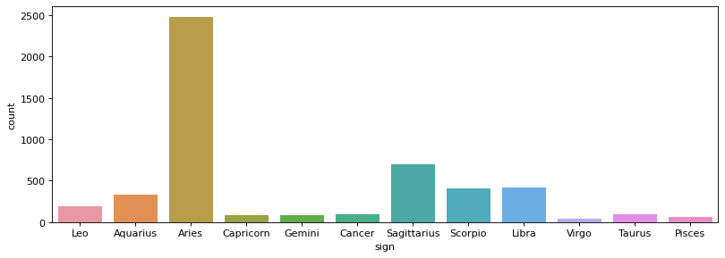

```python
# Distribution of data based on the horoscopic sign

figure(figsize=(12, 4), dpi=80)
sns.countplot(x='sign',data=raw_df)
```

```python
# Value count of each topic in the dataset

raw_df.topic.value_counts()
```

```
Technology              2332
indUnk                  1381
Student                  569
Engineering              119
Education                118
BusinessServices          87
Sports-Recreation         75
InvestmentBanking         70
Communications-Media      61
Non-Profit                47
Science                   33
Arts                      31
Internet                  20
Banking                   16
Consulting                16
Automotive                14
Religion                   4
Law                        3
Museums-Libraries          2
Accounting                 2
Name: topic, dtype: int64
```

Out of all the topics, only 5 topics have more than 100 rows of data and just 3 topics have more than 500 rows of data

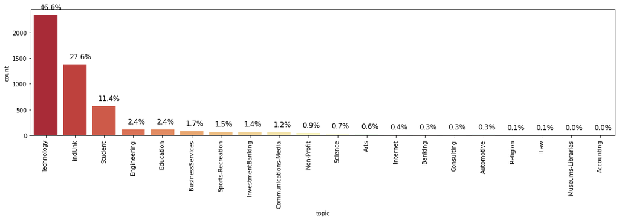

```python
# Percentage distribution of each topic

plt.figure(figsize=(18, 4))
ax = sns.countplot(x=raw_df['topic'], order=raw_df['topic'].value_counts().index, palette = 'RdYlBu');
plt.xticks(rotation = 'vertical');

total = sum(raw_df['topic'].value_counts())

for p in ax.patches:
    ax.annotate('{:.1f}%'.format(100*p.get_height()/total),
                (p.get_x(), p.get_height()),
                 size=12,
                 xytext = (10, 10),
                 textcoords = 'offset points')
```

The dataset is highly imabalanced, with the top 3 topics contributing to 85.6% of the data

```python
raw_df.apply(lambda x: len(x.unique()))
```

```
id          99
gender       2
age         20
topic       20
sign        12
date       573
text      4978
dtype: int64
```

We can see some duplicates in the dataset

```python
raw_df.duplicated().sum()
```

```
13
```

13 rows are duplicate rows

```python
raw_df['text'].duplicated().sum()
```

```
22
```

22 texts are duplicates

```python
raw_df.drop_duplicates(subset=['text'], keep='first', inplace=True)
print('After removing rows with duplicate texts, the shape of the dataset is:', raw_df.shape)
```

```
After removing rows with duplicate texts, the shape of the dataset is: (4978, 7)
```

```python
# Reset index

raw_df.reset_index(drop=True, inplace =True)
```

```python
raw_df.loc[716].text
```

```
'                        '
```

There are no null values in the dataset, but some of the texts are having only blank spaces. These are removed by exception handling in the below lang_detect function

```python
# Removing non-english textual data using 'langdetect' library

len_raw_df = len(raw_df)

def lang_detect (n=0,count_not_en = 0, blank_spaces = 0):
  try:
    for i in range (n,len_raw_df):
      text_lang = detect(raw_df.loc[i].text)
      if text_lang != 'en':
        print(i, '\t', count_not_en+1, '\t', text_lang, '\t\t\t', raw_df.loc[i].text)
        raw_df.drop(index=i, inplace=True)
        count_not_en += 1

    print('\n\n\n',count_not_en, ' Non-English textual data found using langdetect library\n',blank_spaces,' out of ',count_not_en,' are only blank spaces', sep='')

  except:
    print (i, '\t', count_not_en+1, '\t', 'LangDetectException', '\t', raw_df.loc[i].text)
    raw_df.drop(index=i, inplace=True)
    count_not_en += 1
    blank_spaces += 1
    lang_detect(i+1,count_not_en,blank_spaces)

lang_detect()
```

```
1 	 1 	 nl 			            These are the team members:   Drewes van der Laag           urlLink mail  Ruiyu Xie                     urlLink mail  Bryan Aaldering (me)          urlLink mail
150 	 2 	 af 			         &nbsp;    &nbsp;
237 	 3 	 fr 			         'One chance'
318 	 4 	 sl 			                ARGH    ARGHHHHHH. No job......
325 	 5 	 nl 			                Hee hee hee...   Got this link via  urlLink  Debbie's Blog  , and....
437 	 6 	 no 			               NEW SHPIEL!!!
716 	 7 	 LangDetectException
751 	 8 	 id 			         urlLink Making A Resume
753 	 9 	 ro 			         urlLink Write A Resume
754 	 10 	 ro 			         urlLink Resume Service
755 	 11 	 de 			         urlLink Resume Form
756 	 12 	 de 			         urlLink Resume Writing
757 	 13 	 nl 			         urlLink resume help
759 	 14 	 no 			         urlLink cover letter
760 	 15 	 no 			         urlLink resume cover letter
```

[output cut: 255 more lines]

```python
print('After removing Non-English textual data, the shape of the dataset is:', raw_df.shape)
```

```
After removing Non-English textual data, the shape of the dataset is: (4713, 7)
```

```python
# Reset index

raw_df.reset_index(drop=True, inplace =True)
```

```python
# Drop id, gender, age, sign and date columns

raw_df.drop(labels=['id', 'gender', 'age', 'sign', 'date'], axis=1,inplace=True)
```

```python
raw_df.head()
```

|  | topic | text |
| --- | --- | --- |
| 0 | Student | Info has been found (+/- 100 pages,... |
| 1 | Student | In het kader van kernfusie op aarde... |
| 2 | Student | testing!!! testing!!! |
| 3 | InvestmentBanking | Thanks to Yahoo!'s Toolbar I can ... |
| 4 | InvestmentBanking | I had an interesting conversation... |

```python
raw_df.loc[1].text
```

```
"           In het kader van kernfusie op aarde:  MAAK JE EIGEN WATERSTOFBOM   How to build an H-Bomb From: ascott@tartarus.uwa.edu.au (Andrew Scott) Newsgroups: rec.humor Subject: How To Build An H-Bomb (humorous!) Date: 7 Feb 1994 07:41:14 GMT Organization: The University of Western Australia  Ori…
```

```python
detect(raw_df.loc[1].text)
```

```
'en'
```

```python
detect('In het kader van kernfusie op aarde:  MAAK JE EIGEN WATERSTOFBOM')
```

```
'af'
```

'langdetect' library has done a good job of removing non-english textual data. But some texts like the one above has most words from english language and some words from other language, due to which it has predicted it as english based on higher probability of english language

```python
# Value count of each topic after dropping the unnecessary rows

raw_df['topic'].value_counts()
```

```
Technology              2131
indUnk                  1336
Student                  547
Engineering              119
Education                116
Sports-Recreation         75
BusinessServices          74
InvestmentBanking         70
Communications-Media      61
Non-Profit                46
Science                   31
Arts                      31
Internet                  20
Banking                   16
Consulting                15
Automotive                14
Religion                   4
Law                        3
Museums-Libraries          2
Accounting                 2
Name: topic, dtype: int64
```

1. Preprocess unstructured data to make it consumable for model training. [5 Marks]
- A. Eliminate All special Characters and Numbers [2 Marks]
- B. Lowercase all textual data [1 Marks]
- C. Remove all Stopwords [1 Marks]
- D. Remove all extra white spaces [1 Marks]

```python
# Text from row index 3 is taken as reference to verify all the preprocessing steps

raw_df.loc[3].text
```

```
"             Thanks to Yahoo!'s Toolbar I can now 'capture' the URLs of popups...which means now I can show you some cool links to Korean Pop (K-Pop) audio and video without the need to relate instructions like: 'go to the site, click on the pop-audio button then choose...'.  So, without further ad…
```

```python
# Eliminating all special characters and numbers

raw_df.text = raw_df.text.apply(lambda s : re.sub("[^a-zA-Z ]+","",s))
```

```python
raw_df.loc[3].text
```

```
'             Thanks to Yahoos Toolbar I can now capture the URLs of popupswhich means now I can show you some cool links to Korean Pop KPop audio and video without the need to relate instructions like go to the site click on the popaudio button then choose  So without further ado here is the link t…
```

```python
# Lowercase all textual data

raw_df.text = raw_df.text.apply(lambda s: s.lower())
```

```python
raw_df.loc[3].text
```

```
'             thanks to yahoos toolbar i can now capture the urls of popupswhich means now i can show you some cool links to korean pop kpop audio and video without the need to relate instructions like go to the site click on the popaudio button then choose  so without further ado here is the link t…
```

```python
# Removing all english stopwords and extra white spaces

stopwords=set(stopwords.words('english'))
raw_df.text = raw_df.text.apply(lambda t: ' '.join([words for words in t.split() if words not in stopwords]) )
```

```python
raw_df.loc[3].text
```

```
'thanks yahoos toolbar capture urls popupswhich means show cool links korean pop kpop audio video without need relate instructions like go site click popaudio button choose without ado link hour kpop urllink audio urllink video streaming enjoy'
```

```python
raw_df.head()
```

|  | topic | text |
| --- | --- | --- |
| 0 | Student | info found pages mb pdf files wait untill team... |
| 1 | Student | het kader van kernfusie op aarde maak je eigen... |
| 2 | Student | testing testing |
| 3 | InvestmentBanking | thanks yahoos toolbar capture urls popupswhich... |
| 4 | InvestmentBanking | interesting conversation dad morning talking k... |

```python
raw_df.shape
```

```
(4713, 2)
```

1. Build a base Classification model [8 Marks]
- A. Create dependent and independent variables [2 Marks]
  - Hint: Treat ‘topic’ as a Target variable.
- B. Split data into train and test. [1 Marks]
- C. Vectorize data using any one vectorizer. [2 Marks]
- D. Build a base model for Supervised Learning - Classification. [2 Marks]
- E. Clearly print Performance Metrics. [1 Marks]
  - Hint: Accuracy, Precision, Recall, ROC-AUC

```python
# Creating dependent and independent variables

X = raw_df.text
y = raw_df.topic
```

```python
from sklearn.preprocessing import LabelEncoder
# Encode labels

le = LabelEncoder()
```

```python
# Dependent variable before label encoding

y
```

```
0                 Student
1                 Student
2                 Student
3       InvestmentBanking
4       InvestmentBanking
              ...
4708               indUnk
4709               indUnk
4710               indUnk
4711               indUnk
4712               indUnk
Name: topic, Length: 4713, dtype: object
```

```python
# Label encoding the dependent variable

y = le.fit_transform(y)
```

```python
# Dependent variable after label encoding

y
```

```
array([17, 17, 17, ..., 19, 19, 19])
```

```python
# Split X and y into training and testing sets

X_train, X_test, y_train, y_test = train_test_split(X,y, random_state=2,test_size = 0.3)
```

```python
print(X_train.shape)
print(y_train.shape)
print(X_test.shape)
print(y_test.shape)
```

```
(3299,)
(3299,)
(1414,)
(1414,)
```

```python
# Vectorizing data using count vectorizer

cvect = CountVectorizer(ngram_range=(1,2))
cvect.fit(X_train)

#Check the vocablury size
len(cvect.vocabulary_)
```

```
244315
```

```python
cvect.get_feature_names()[:10]
```

```
['aa',
 'aa amazing',
 'aa anger',
 'aa compared',
 'aa nice',
 'aaa',
 'aaa take',
 'aaaaaaah',
 'aaaaaaah fade',
 'aaaaaah']
```

```python
# Vectorizing data using count vectorizer

X_train_ct = cvect.transform(X_train)
X_test_ct = cvect.transform(X_test)
```

```python
# Shape of data before count vectorization

print(X_test.shape)
print(X_train.shape)
```

```
(1414,)
(3299,)
```

```python
# Shape of data after count vectorization

print(X_test_ct.shape)
print(X_train_ct.shape)
```

```
(1414, 244315)
(3299, 244315)
```

```python
# Creating label list for confusion matrix

act_y_list = []
pred_y_list = []

for i in np.unique(y):
  act_y_list.append('Act_'+str(i)+'_'+le.inverse_transform([i])[0])
  pred_y_list.append('Pred_'+str(i)+'_'+le.inverse_transform([i])[0])
```

```python
# Base model for Supervised Learning - Classification (Logistic Regression) with count vectorizer

model=LogisticRegression(solver='lbfgs', max_iter=5)
model=OneVsRestClassifier(model)
model.fit(X_train_ct,y_train)
pred=model.predict(X_test_ct)
```

```python
# Performance metrics

print(classification_report(y_test, pred))
```

```
              precision    recall  f1-score   support

           0       0.00      0.00      0.00         1
           1       0.00      0.00      0.00        12
           2       0.00      0.00      0.00         5
           3       0.00      0.00      0.00         5
           4       1.00      0.10      0.17        21
           5       0.00      0.00      0.00        12
           6       0.00      0.00      0.00         6
           7       0.67      0.05      0.09        41
           8       0.88      0.35      0.50        43
           9       0.00      0.00      0.00         9
          10       1.00      0.58      0.73        19
          11       0.00      0.00      0.00         1
          13       0.00      0.00      0.00         8
          15       1.00      0.14      0.25         7
          16       1.00      0.54      0.70        24
          17       0.56      0.37      0.44       156
          18       0.69      0.97      0.80       642
          19       0.65      0.58      0.61       402

    accuracy                           0.68      1414
   macro avg       0.41      0.20      0.24      1414
weighted avg       0.65      0.68      0.63      1414
```

The base Supervised Learning model, Logistic Regression with solver='lbfgs' and max_iter=5 and the vectorizer being count vectorizer has given an accuracy of 68% and weighted average F1 score of 63%

```
Confusion Matrix
```

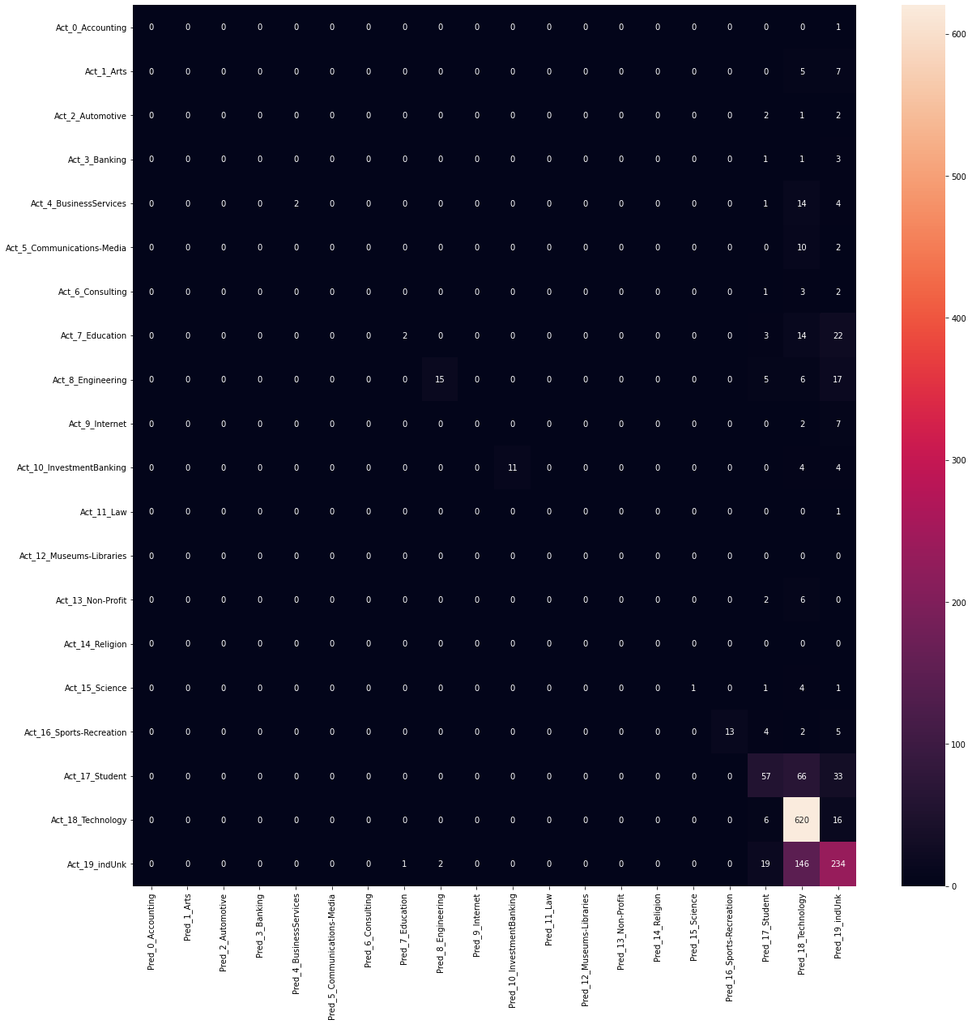

```python
# Confusion matrix

print("Confusion Matrix")
cm=metrics.confusion_matrix(y_test, pred, labels=list(np.unique(y)))

df_cm = pd.DataFrame(cm, index = [i for i in act_y_list],
                  columns = [i for i in pred_y_list])
plt.figure(figsize = (20,20))
sns.heatmap(df_cm, annot=True, fmt='d')
```

1. Improve Performance of model. [14 Marks]
- A. Experiment with other vectorisers. [4 Marks]
- B. Build classifier Models using other algorithms than base model. [4 Marks]
- C. Tune Parameters/Hyperparameters of the model/s. [4 Marks]
- D. Clearly print Performance Metrics. [2 Marks]
  - Hint: Accuracy, Precision, Recall, ROC-AUC

```python
# Vectorizing data using Tf-idf vectorizer

tfvect = TfidfVectorizer()
tfvect.fit(X_train)

#Check the vocablury size
len(tfvect.vocabulary_)
```

```
32316
```

```python
tfvect.get_feature_names()[:10]
```

```
['aa',
 'aaa',
 'aaaaaaah',
 'aaaaaah',
 'aaaaaawwwwww',
 'aaaaack',
 'aaaaahhhh',
 'aaaghpero',
 'aaahhha',
 'aaahhhh']
```

```python
# Vectorizing data using Tf-idf vectorizer

X_train_tf = tfvect.transform(X_train)
X_test_tf = tfvect.transform(X_test)
```

```python
# Shape of data after Tf-idf vectorization

print(X_test_tf.shape)
print(X_train_tf.shape)
```

```
(1414, 32316)
(3299, 32316)
```

```python
# Base model for Supervised Learning - Classification (Logistic Regression) with Tf-idf vectorizer

model=LogisticRegression(solver='lbfgs', max_iter=5)
model=OneVsRestClassifier(model)
model.fit(X_train_tf,y_train)
pred=model.predict(X_test_tf)
```

```python
# Performance metrics

print(classification_report(y_test, pred))
```

```
              precision    recall  f1-score   support

           0       0.00      0.00      0.00         1
           1       0.00      0.00      0.00        12
           2       0.00      0.00      0.00         5
           3       0.00      0.00      0.00         5
           4       0.00      0.00      0.00        21
           5       0.00      0.00      0.00        12
           6       0.00      0.00      0.00         6
           7       0.00      0.00      0.00        41
           8       0.00      0.00      0.00        43
           9       0.00      0.00      0.00         9
          10       0.00      0.00      0.00        19
          11       0.00      0.00      0.00         1
          13       0.00      0.00      0.00         8
          15       0.00      0.00      0.00         7
          16       0.00      0.00      0.00        24
          17       0.00      0.00      0.00       156
          18       0.73      0.92      0.81       642
          19       0.48      0.72      0.58       402

    accuracy                           0.62      1414
   macro avg       0.07      0.09      0.08      1414
weighted avg       0.47      0.62      0.53      1414
```

The base Supervised Learning model, Logistic Regression with solver='lbfgs' and max_iter=5 and the vectorizer being Tf-idf vectorizer has given an accuracy of 62% and weighted average F1 score of 53%

But the base model with Tf-idf vectorizer has predicted all the data as only two labels (18-Technology and 19-indUnk)

```
Confusion Matrix
```

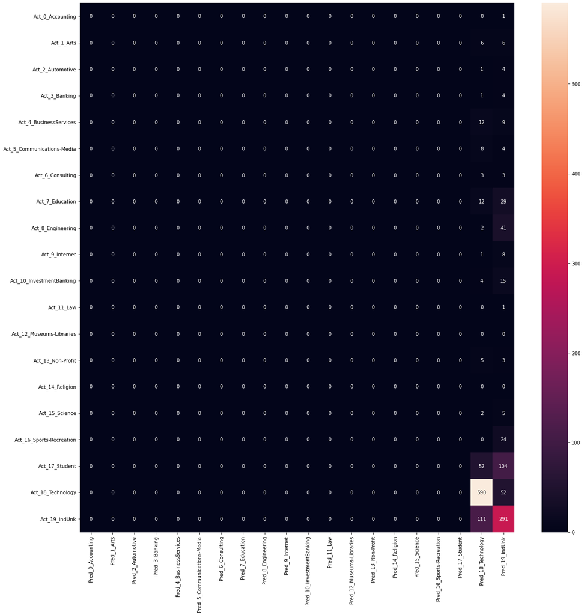

```python
# Confusion matrix

print("Confusion Matrix")
cm=metrics.confusion_matrix(y_test, pred, labels=list(np.unique(y)))

df_cm = pd.DataFrame(cm, index = [i for i in act_y_list],
                  columns = [i for i in pred_y_list])
plt.figure(figsize = (20,20))
sns.heatmap(df_cm, annot=True, fmt='d')
```

```python
# SVC model with count vectorizer

model = SVC(kernel='rbf', max_iter=5)
model = OneVsRestClassifier(model)
model.fit(X_train_ct,y_train)
pred=model.predict(X_test_ct)
```

```python
# Performance metrics

print(classification_report(y_test, pred))
```

```
              precision    recall  f1-score   support

           0       0.00      0.00      0.00         1
           1       0.01      0.17      0.02        12
           2       0.00      0.00      0.00         5
           3       0.00      0.00      0.00         5
           4       0.02      0.24      0.03        21
           5       0.11      0.08      0.10        12
           6       0.00      0.00      0.00         6
           7       0.12      0.02      0.04        41
           8       0.11      0.14      0.12        43
           9       0.11      0.22      0.15         9
          10       0.02      0.26      0.04        19
          11       0.00      0.00      0.00         1
          13       0.00      0.00      0.00         8
          15       0.00      0.00      0.00         7
          16       0.23      0.25      0.24        24
          17       0.00      0.00      0.00       156
          18       0.67      0.52      0.58       642
          19       0.50      0.01      0.01       402

    accuracy                           0.26      1414
   macro avg       0.11      0.11      0.07      1414
weighted avg       0.46      0.26      0.28      1414
```

SVC model with kernel='rbf' and max_iter=5 and the vectorizer being count vectorizer has given an accuracy of 26% and weighted average F1 score of 28%

```
Confusion Matrix
```

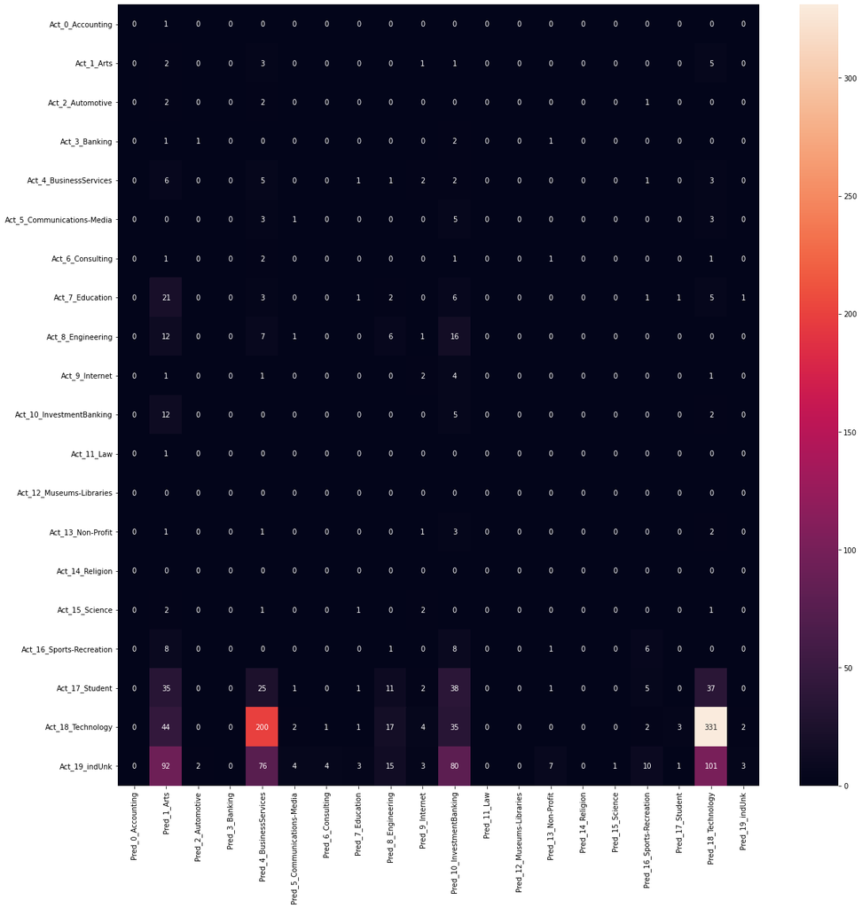

```python
# Confusion matrix

print("Confusion Matrix")
cm=metrics.confusion_matrix(y_test, pred, labels=list(np.unique(y)))

df_cm = pd.DataFrame(cm, index = [i for i in act_y_list],
                  columns = [i for i in pred_y_list])
plt.figure(figsize = (20,20))
sns.heatmap(df_cm, annot=True, fmt='d')
```

```python
# SVC model with Tf-idf vectorizer

model = SVC(kernel='rbf', max_iter=5)
model = OneVsRestClassifier(model)
model.fit(X_train_tf,y_train)
pred=model.predict(X_test_tf)
```

```python
# Performance metrics

print(classification_report(y_test, pred))
```

```
              precision    recall  f1-score   support

           0       0.00      0.00      0.00         1
           1       0.09      0.17      0.12        12
           2       0.20      0.40      0.27         5
           3       0.06      0.20      0.10         5
           4       0.11      0.38      0.17        21
           5       0.20      0.08      0.12        12
           6       0.00      0.00      0.00         6
           7       0.18      0.15      0.16        41
           8       0.10      0.21      0.14        43
           9       0.42      0.56      0.48         9
          10       0.71      0.63      0.67        19
          11       0.00      0.00      0.00         1
          13       0.05      0.25      0.08         8
          15       0.14      0.43      0.21         7
          16       0.25      0.50      0.33        24
          17       0.16      0.22      0.18       156
          18       0.80      0.01      0.01       642
          19       0.26      0.51      0.35       402

    accuracy                           0.22      1414
   macro avg       0.21      0.26      0.19      1414
weighted avg       0.49      0.22      0.16      1414
```

SVC model with kernel='rbf' and max_iter=5 and the vectorizer being Tf-idf has given an accuracy of 22% and weighted average F1 score of 16%

```
Confusion Matrix
```

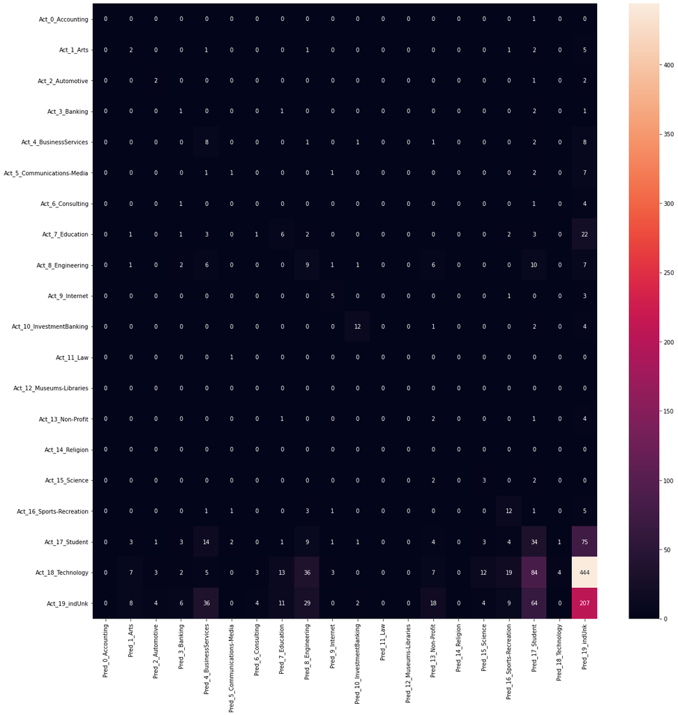

```python
# Confusion matrix

print("Confusion Matrix")
cm=metrics.confusion_matrix(y_test, pred, labels=list(np.unique(y)))

df_cm = pd.DataFrame(cm, index = [i for i in act_y_list],
                  columns = [i for i in pred_y_list])
plt.figure(figsize = (20,20))
sns.heatmap(df_cm, annot=True, fmt='d')
```

After multiple iterations of tuning the models, below are the best Logistic Regression and SVC models

```python
# Tuned Logistic Regression model with count vectorizer

model=LogisticRegression(C=35, penalty='l1', solver='liblinear', n_jobs=-1, class_weight='balanced')
model=OneVsRestClassifier(model)
model.fit(X_train_ct,y_train)
pred=model.predict(X_test_ct)
```

```python
# Performance metrics

print(classification_report(y_test, pred))
```

```
              precision    recall  f1-score   support

           0       0.00      0.00      0.00         1
           1       0.60      0.25      0.35        12
           2       0.33      0.20      0.25         5
           3       0.75      0.60      0.67         5
           4       0.27      0.19      0.22        21
           5       0.50      0.50      0.50        12
           6       0.50      0.33      0.40         6
           7       0.31      0.20      0.24        41
           8       0.65      0.72      0.68        43
           9       0.40      0.22      0.29         9
          10       0.88      0.74      0.80        19
          11       0.00      0.00      0.00         1
          12       0.00      0.00      0.00         0
          13       0.50      0.25      0.33         8
          14       0.00      0.00      0.00         0
          15       0.00      0.00      0.00         7
          16       0.84      0.88      0.86        24
          17       0.55      0.47      0.51       156
          18       0.77      0.90      0.83       642
          19       0.71      0.63      0.67       402

    accuracy                           0.71      1414
   macro avg       0.43      0.35      0.38      1414
weighted avg       0.69      0.71      0.70      1414
```

The tuned Logistic Regression model with C=35, penalty='l1', solver='liblinear', n_jobs=-1, class_weight='balanced' and the vectorizer being count vectorizer has given an accuracy of 71% and weighted average F1 score of 70%

Though there has not been much improvement from the baseline model. This was observed to be the best tuning possible on Logistic Regression model with count vectorizer

```
Confusion Matrix
```

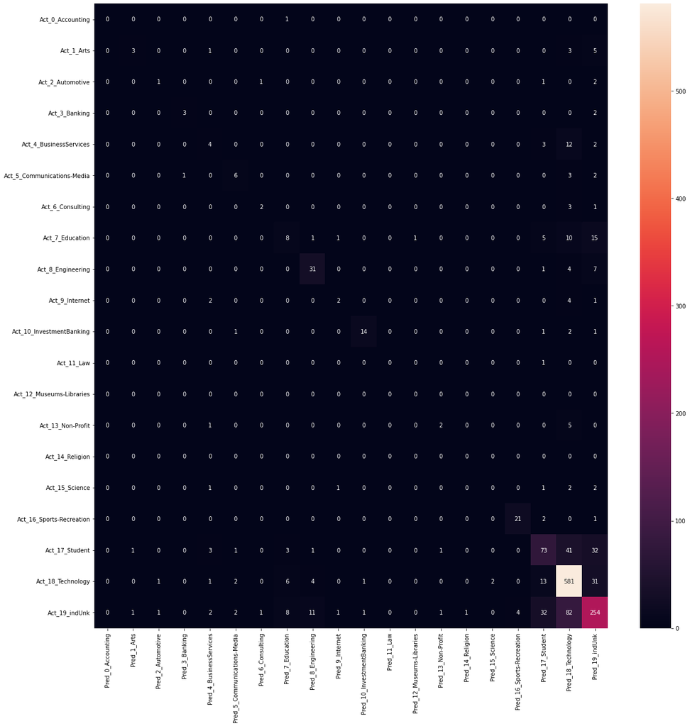

```python
# Confusion matrix

print("Confusion Matrix")
cm=metrics.confusion_matrix(y_test, pred, labels=list(np.unique(y)))

df_cm = pd.DataFrame(cm, index = [i for i in act_y_list],
                  columns = [i for i in pred_y_list])
plt.figure(figsize = (20,20))
sns.heatmap(df_cm, annot=True, fmt='d')
```

```python
# Tuned SVC model with Tf-idf vectorizer

model = SVC(kernel='linear', class_weight='balanced', C=2, gamma=7)
model = OneVsRestClassifier(model)
model.fit(X_train_tf,y_train)
pred=model.predict(X_test_tf)
```

```python
# Performance metrics

print(classification_report(y_test, pred))
```

```
              precision    recall  f1-score   support

           0       0.00      0.00      0.00         1
           1       1.00      0.50      0.67        12
           2       1.00      0.20      0.33         5
           3       0.00      0.00      0.00         5
           4       0.78      0.33      0.47        21
           5       0.75      0.25      0.38        12
           6       0.00      0.00      0.00         6
           7       0.60      0.22      0.32        41
           8       0.87      0.60      0.71        43
           9       1.00      0.22      0.36         9
          10       1.00      0.79      0.88        19
          11       0.00      0.00      0.00         1
          13       1.00      0.12      0.22         8
          15       0.50      0.14      0.22         7
          16       0.91      0.83      0.87        24
          17       0.64      0.57      0.61       156
          18       0.80      0.93      0.86       642
          19       0.71      0.76      0.73       402

    accuracy                           0.76      1414
   macro avg       0.64      0.36      0.42      1414
weighted avg       0.76      0.76      0.75      1414
```

The tuned SVC model with kernel='linear', class_weight='balanced', C=2, gamma=7 and the vectorizer being Tf-idf has given an accuracy of 76% and weighted average F1 score of 75%

This has been observed to be the best model performance on the dataset

```
Confusion Matrix
```

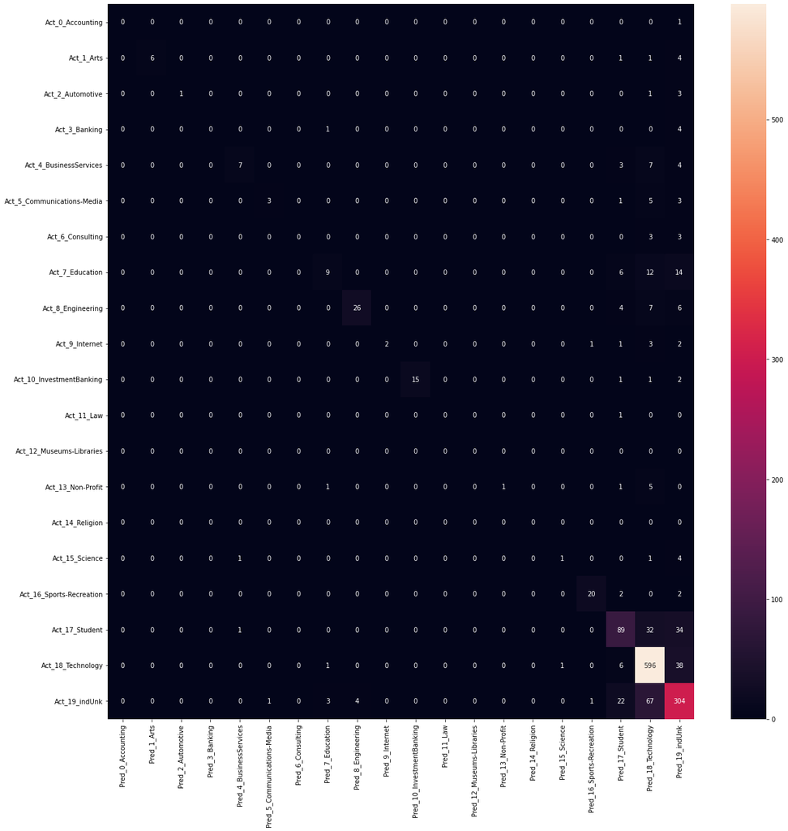

```python
# Confusion matrix

print("Confusion Matrix")
cm=metrics.confusion_matrix(y_test, pred, labels=list(np.unique(y)))

df_cm = pd.DataFrame(cm, index = [i for i in act_y_list],
                  columns = [i for i in pred_y_list])
plt.figure(figsize = (20,20))
sns.heatmap(df_cm, annot=True, fmt='d')
```

Printing the true vs predicted labels for 5 entries from the testing database

```python
print(le.inverse_transform(pred)[100])
print(le.inverse_transform(y_test)[100])
```

```
Technology
Technology
```

```python
print(le.inverse_transform(pred)[200])
print(le.inverse_transform(y_test)[200])
```

```
Technology
Technology
```

```python
print(le.inverse_transform(pred)[300])
print(le.inverse_transform(y_test)[300])
```

```
indUnk
indUnk
```

```python
print(le.inverse_transform(pred)[400])
print(le.inverse_transform(y_test)[400])
```

```
Technology
Student
```

```python
print(le.inverse_transform(pred)[500])
print(le.inverse_transform(y_test)[500])
```

```
Technology
Technology
```

On the above random samples, the best model has correctly predicted 4 out of 5 times

1. Share insights on relative performance comparison [8 Marks]
- A. Which vectorizer performed better? Probable reason?. [2 Marks]
- B. Which model outperformed? Probable reason? [2 Marks]
- C. Which parameter/hyperparameter significantly helped to improve performance?Probable reason?. [2 Marks]
- D. According to you, which performance metric should be given most importance, why?. [2 Marks]

## A

TF-IDF is better than Count Vectorizers because it not only focuses on the frequency of words present in the corpus but also provides the importance of the words. We can then remove the words that are less important for analysis, hence making the model building less complex by reducing the input dimensions.

In our case, the base models performed slightly better with count vectorizer but the best tuned model had TF-IDF vectorizer.

It is always recommended to try out different vectorizers and model combinations as we never know which model performs best with which vectorizer.

Even though TFIDF can provide a good understanding about the importance of words but just like Count Vectors, its disadvantage is that, it fails to provide linguistic information about the words such as the real meaning of the words, similarity with other words, etc.

To train a model on the actual linguistic relationship of the words, there are two other word embedding techniques in NLP, they are “word2vec” and “Glove”.

## B

If we consider the baseline model, the Logistic Regression models performed much better than the SVC models.

After tuning, they had similar performances but the best SVC model marginally outperformed the best Logistic Regression model.

In theory, SVC minimizes hinge loss while Logistic Regression minimizes logistic loss.

1. Logistic loss diverges faster than hinge loss. So, in general, it will be more sensitive to outliers.
2. Logistic loss does not go to zero even if the point is classified sufficiently confidently. This might lead to minor degradation in accuracy.

So, you can typically expect SVM to perform marginally better than Rogistic Regression.

## C

In case of Logistic Regression models, hyperparameter tuning did not much help in drastically improving the performance of the model. But after playing with a lot of parameters, there was just a marginal improvement.

This is because, the performance of a SVC model on a dataset highly depends on the way the dataset is seperable. So choosing the right kernel reduces the computational expense and improves the prediction by large.

## D

In our case both precision and recall, both are important. Given that, F1 score is a way of combining the precision and recall of the model, we should give most importance to F1 score.

If you have an imbalanced dataset, then the weighted average is preferred.This is because, in weighted averaging, the contribution of each class to the F1 average is weighted by its size. Hence, the most importance should be given to weighted average F1 score.

# Part B

Design a python based interactive semi - rule based chatbot which can do the following:

1. Start chat session with greetings and ask what the user is looking for. [5 Marks]
2. Accept dynamic text based questions from the user. Reply back with relevant answer from the designed corpus. [10 Marks]
3. End the chat session only if the user requests to end else ask what the user is looking for. Loop continues till the user asks to end it. [5 Marks]

```python
# Importing all the necessary libraries

import numpy as np
from sklearn.preprocessing import LabelEncoder

import nltk
from nltk.corpus import wordnet
from nltk.stem import WordNetLemmatizer
import re

import keras, tensorflow
from keras.models import Sequential
from keras.layers import Dense, Embedding, GlobalAveragePooling1D

from tensorflow.keras.preprocessing.text import Tokenizer
from tensorflow.keras.layers import BatchNormalization, Dropout
from tensorflow.keras.preprocessing.sequence import pad_sequences

import json
import random
import pickle

from nltk.stem import WordNetLemmatizer
import string
```

```python
# import corpus file
with open('GL Bot.json') as file:
    corpus = json.load(file)

# Display corpus file
print(corpus)
```

```
{'intents': [{'tag': 'Intro', 'patterns': ['hi', 'how are you', 'is anyone there', 'hello', 'whats up', 'hey', 'yo', 'listen', 'please help me', 'i am learner from', 'i belong to', 'aiml batch', 'aifl batch', 'i am from', 'my pm is', 'blended', 'online', 'i am from', 'hey ya', 'talking to you for fi…
```

```python
# List initialization
corp1 = corpus["intents"]
corp2 = [
    {'tag': 'options',
     'patterns': ["How can you help me", "What can you do", "What help you provide", "What do you know"],
     'responses': ["I can guide you with machine learning and artificial learning concepts", "I can assist you with your program"],
     'context_set': ''
    },
    {'tag': 'SL',
     'patterns': ['bias-variance tradeoff', 'support vector machines', 'normalization', 'Can you help me understand svm',
                  'could you please explain me how machine learning works', 'K nearest neighbor algorithm'
                  'Could me help me understand naive bayes', 'decision trees', 'labeled data', 'supervised', 'Do you know KNN',
                  'Can you help me with KNN algorithm', 'Can you explain KNN', 'Can you help me with supervised ML?'],
     'responses': ['Link: https://en.wikipedia.org/wiki/Supervised_learning'],
     'context_set': ''
    },
    {'tag': 'USL',
     'patterns': ['PCA', 'Pricipal component analysis', 'K means clustering', 'dimensionality reduction', 'unlabeled data'
                  'clustering', 'K nearest neighbor algorithm', 'clustering', 'association', 'hierarchical clustering'
                  'Singular value decomposition', 'Do you know PCA'],
     'responses': ['Link: https://en.wikipedia.org/wiki/Unsupervised_learning'],
     'context_set': ''
    },
    {'tag': 'NN',
     'patterns': ['RelU', 'sigmoid function', 'tanh', 'optimizer', 'neural networks', 'Can you help me with deep learning',
                  'ANN', 'CNN', 'Transfer learning'],
     'responses': ['Link: https://en.wikipedia.org/wiki/Artificial_neural_network'],
     'context_set': ''
    },
    {'tag': 'Bot',
     'patterns': ['May I know who you are', "whats you're name"],
     'responses': ["I'm your virtual assistant and I'm 24x7 available"],
     'context_set': ''
    },
    {'tag': 'no answer',
     'patterns': [],
     'responses': ["Sorry, I can't understand you", "Please give me more info", "Unable to understand you, Can you provide info"],
     'context_set': ''
    },
    {'tag': 'Intro',
     'patterns': ['How do you do', 'Hi.. Can you help me with my issue', 'Are you there', "what's up", "Howdy",
                  'Could you please help me', 'I need you to listen to me', 'I belong to a new batch of',
                  'Artificial Intelligence class', 'AI & ML batch', 'Machine Learning batch', 'My Program Manager is'],
     'responses': ['Hi there, how can I help you', 'Good to see you again', 'Hello thanks for asking',
                   'Hello, How may I help you'],
     'context_set': ''
    },
    {'tag': 'Exit',
     'patterns': ["that was very helpful", 'thanks again', 'awesome, thanks', 'thanks for helping me out',
                  'will catch you later', "i'll take a leave", 'have a Great day', 'you helped a lot',
                  'you are a great learning buddy', 'bye', 'good bye'],
     'responses': ['Anytime!!', "Happy to help!", "My pleasure!", "Glad I could assist you"],
     'context_set': ''
    },
    {'tag': 'Ticket',
     'patterns': ['my issue is not solved', 'you answer did not help', 'I did not get the answer', 'solution was not good',
                  'you did not help', 'I want to talk to a my PM', 'connect me to the program manager',
                  'I want to raise a ticket', 'no'],
     'responses': ['Transferring the request to your PM', 'Please wait while I transfer your request to PM'],
     'context_set': ''
    }
    ]
```

```python
# Iterating and using extend to convert
for elm2 in corp2:

    for elm1 in corp1:
        if elm2['tag'] == elm1['tag']:
            elm1['responses'].extend(elm2['responses'])
            break
    else:
        corp1.append(elm2)
```

```python
corpus["intents"] = corp1
```

```python
print(corpus['intents'])
```

```
[{'tag': 'Intro', 'patterns': ['hi', 'how are you', 'is anyone there', 'hello', 'whats up', 'hey', 'yo', 'listen', 'please help me', 'i am learner from', 'i belong to', 'aiml batch', 'aifl batch', 'i am from', 'my pm is', 'blended', 'online', 'i am from', 'hey ya', 'talking to you for first time'], …
```

## Data pre-processing

```python
# Extract required data from the corpus
train_sentences = [] #tokens
train_labels = []    #identified tags or labels

labels = []
responses = []

for intent in corpus ['intents']:
    for pattern in intent['patterns']:

        train_sentences.append(pattern)
        train_labels.append(intent['tag'])

    responses.append(intent['responses'])

    #Add missing tag if any
    if intent['tag'] not in labels:
        labels.append(intent['tag'])

num_classes = len(labels)
```

We use “LabelEncoder()” function provided by scikit-learn to convert the target labels into a model understandable form.

```python
lbl_encoder = LabelEncoder()
lbl_encoder.fit(train_labels)
train_labels = lbl_encoder.transform(train_labels)
```

Let us vectorize our text data corpus by using the “Tokenizer” class and it allows us to limit our vocabulary size up to some defined number. When we use this class for the text pre-processing task, by default all punctuations will be removed, turning the texts into space-separated sequences of words, and these sequences are then split into lists of tokens. They will then be indexed or vectorized. We can also add “oov_token” which is a value for “out of token” to deal with out of vocabulary words(tokens) at inference time. The “pad_sequences” method is used to make all the training text sequences into the same size.

```python
vocab_size = 100000
embedding_dim = 16
max_len = 20
oov_token = "<OOV>"

tokenizer = Tokenizer(num_words=vocab_size, oov_token=oov_token)
tokenizer.fit_on_texts(train_sentences)

word_index = tokenizer.word_index

sequences = tokenizer.texts_to_sequences(train_sentences)
padded_sequences = pad_sequences(sequences, truncating='post', maxlen=max_len)
```

## Model training

```python
model = Sequential()

model.add(Embedding(vocab_size, embedding_dim, input_length=max_len))
model.add(GlobalAveragePooling1D())
model.add(Dense(16, activation='relu'))
model.add(Dense(16, activation='relu'))
model.add(Dense(num_classes, activation='softmax'))

model.compile(loss='sparse_categorical_crossentropy', optimizer='adam', metrics=['accuracy'])

model.summary()
```

```
Model: "sequential"
_________________________________________________________________
 Layer (type)                Output Shape              Param #
=================================================================
 embedding (Embedding)       (None, 20, 16)            1600000

 global_average_pooling1d (G  (None, 16)               0
 lobalAveragePooling1D)

 dense (Dense)               (None, 16)                272

 dense_1 (Dense)             (None, 16)                272

 dense_2 (Dense)             (None, 11)                187

=================================================================
Total params: 1,600,731
Trainable params: 1,600,731
Non-trainable params: 0
_________________________________________________________________
```

```python
# Fit  the model
epochs = 500
history = model.fit(padded_sequences, np.array(train_labels), epochs=epochs)
```

```python
# to save the trained model
model.save("bot")

# to save the fitted tokenizer
with open('tokenizer.pickle', 'wb') as handle:
    pickle.dump(tokenizer, handle, protocol=pickle.HIGHEST_PROTOCOL)

# to save the fitted label encoder
with open('label_encoder.pickle', 'wb') as ecn_file:
    pickle.dump(lbl_encoder, ecn_file, protocol=pickle.HIGHEST_PROTOCOL)
```

```
INFO:tensorflow:Assets written to: bot/assets
```

## Inference

The chatbot will calculate the similarity between the new text sequence and training data. Considering the confidence scores got for each category, it categorizes the user message to an intent with the highest confidence score.

```python
def chat():
    # load trained model
    model = keras.models.load_model('bot')

    # load tokenizer object
    with open('tokenizer.pickle', 'rb') as handle:
        tokenizer = pickle.load(handle)

    # load label encoder object
    with open('label_encoder.pickle', 'rb') as enc:
        lbl_encoder = pickle.load(enc)

    # parameters
    max_len = 20

    print ("Welcome to Great Learning.")
    print ("I'm your GL virtual assistant. How may I help you?")
    print ("Note: You can type 'quit' to end the session")

    # While loop to run the chatbot indefinetely
    while True:
        print("")
        print("User: ", end="")

        # Takes the user input and converts all characters to lowercase
        inp = input()

        # Defining the Chatbot's exit condition
        if inp.lower() == "quit":
            print("Bot: Thank you for visiting Great Learning support. Stay safe.")
            break

        result = model.predict(keras.preprocessing.sequence.pad_sequences(tokenizer.texts_to_sequences([inp]),
                                             truncating='post', maxlen=max_len))
        tag = lbl_encoder.inverse_transform([np.argmax(result)])


        count = 0
        matched_intent = None

        for i in corpus['intents']:

            if i['tag'] == tag:
                print("Bot:", np.random.choice(i['responses']))

chat()
```

```
Welcome to Great Learning.
I'm your GL virtual assistant. How may I help you?
Note: You can type 'quit' to end the session

User: hi
Bot: Good to see you again

User: who are you
Bot: I'm your virtual assistant and I'm 24x7 available

User: what can you do
Bot: I can guide you with machine learning and artificial learning concepts

User: could you help me understand naive bayes
Bot: Link: Machine Learning wiki

User: thank you
Bot: I hope I was able to assist you, Good Bye

User: quit
Bot: Thank you for visiting Great Learning support. Stay safe.
```